# 📊 Introducción al curso y a la EPH

Módulo 1 - Aspectos metodológicos de la encuesta

Pablo Tiscornia

[Estación R](https://estacion-r.com/)

2026-03-10

# Bienvenidos y bienvenidas a Estación R

## Contacto con Estación R

#### 💬 [Slack](https://estacion-r.slack.com/)

#### 🔗 [Web](https://estacion-r.com)

#### ✉️ Correo

#### 🐘 [Mastodon](https://botsin.space/@r_tips)

#### 𝕏 [X](https://twitter.com/estacion_erre)

#### [in] [LinkedIn](https://www.linkedin.com/company/estacion-r/)

#### [ig] [Instagram](https://instagram.com/estacion_ere)

# El curso 📚

## Programa del curso

| Módulo | Tema |
| --- | --- |
| **1** | Introducción al curso y a la EPH |
| **2** | Introducción a R + IA en análisis de datos |
| **3** | tidyverse I: Importación y selección |
| **4** | tidyverse II: Transformación y resumen |
| **5** | Proyectos y organización de trabajo |
| **6** | Visualización con ggplot2 + TP integrador |

## Dinámica de trabajo

### 📅 6 encuentros de 2:30 hs cada uno (martes 19hs ARG)

### 📝 Ejercitación semanal (no obligatoria)

### 🎯 Trabajo práctico integrador al final

### 🎥 Grabación de todos los encuentros

### 💬 Comunicación por **Slack**

## Página de Estación R

### 🔗 [estacion-r.github.io/intro-r-sociales](https://estacion-r.github.io/intro-r-sociales/)

*Vamos a recorrer la página juntos…*

## Presentémonos 🙋

Contanos en el chat o en voz:

- 👤 Tu **nombre**
- 🌍 De dónde **sos**
- 💼 ¿Qué **hacés**? (trabajo, estudio)
- 🤔 ¿Por qué te **interesa R**?
- 💻 ¿Tenés **experiencia previa** con R u otro lenguaje?

# ¿Qué es la EPH? 📋

[figure not shown]

## Marco analítico conceptual

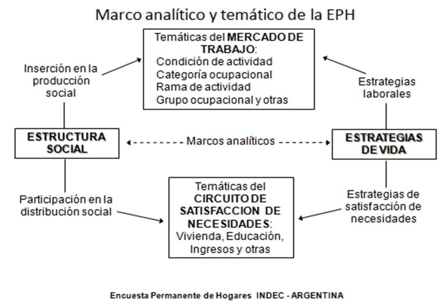

# Fuentes de datos

## Tipos de fuentes

### 📊 Censos

*Le pregunto a TODA la población sobre sus características*

### 📁 Registros administrativos

*La población está registrada en formularios (con fines estadísticos o no)*

### 📝 Encuestas

*No puedo acceder a toda la población, le pregunto sólo a una porción*

### 📱 Dispositivos interconectados

*La población “deja” rastros en celulares, internet, operaciones digitales*

# Objetivos de la EPH

## Objetivo general

El **objetivo general** de la encuesta es el análisis de la **inserción de la población en la estructura económico-social**.

Dicha inserción puede ser analizada a partir de tres ejes:

1. Características **demográficas**
2. Inserción en la **producción** de bienes y servicios
3. Participación en la **distribución** del producto social

# Características de la EPH

## Historia de la EPH

[figure not shown]

## Cobertura geográfica

- **Dominio de estimación:** Principales aglomerados urbanos
- Fue creciendo progresivamente hasta llegar a **31 aglomerados urbanos**:
  - Todas las capitales de provincia
  - Aglomerados con +100.000 habitantes
- **Concepto de aglomerado:** *“Dos localidades distintas pero próximas que conforman un único mercado de trabajo”*

## ¿A quiénes representa?

- La encuesta representa al **65%** del total de la población argentina
- Una vez al año se releva la **EAHU** (extensión al 100% de población urbana)
- Proyecto en pruebas: cobertura del ámbito rural

# La Muestra 🎯

## ¿Qué es una muestra?

La EPH es una **encuesta por muestreo**: se selecciona un grupo de hogares que representan al conjunto del universo.

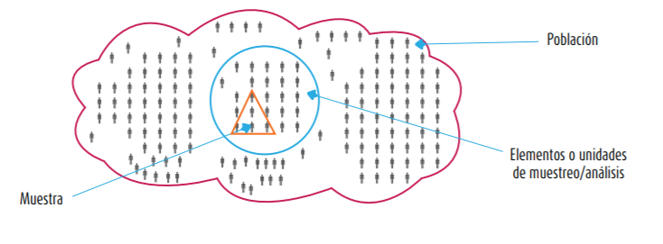

Fuente: Hernández-Sampieri, “Metodología de la Investigación”

## Tamaño de la muestra

Por cada trimestre se relevan aproximadamente:

- **~18.000 hogares** (representan a más de 9 millones)
- **~58.000 personas** (representan a más de 27 millones)

## Diseño muestral

**Diseño bietápico estratificado:**

1. **Primera etapa:** Se seleccionan **radios censales** (áreas) dentro de cada aglomerado
2. **Segunda etapa:** Se listan las **viviendas** del área y se seleccionan aleatoriamente

**Esquema de rotación:** 2-2-2

*(Un hogar está en muestra 2 trimestres, sale 2 trimestres, y vuelve 2 trimestres)*

# Principales temáticas 📊

## ¿Qué mide la EPH?

- Características **demográficas** básicas
- Características **ocupacionales** (empleo, desempleo, informalidad)
- Características **migratorias**
- Características **habitacionales**
- Características **educacionales**
- Características de **ingreso**

# Tres cuestionarios 📝

## Cuestionario de Vivienda 🏠

**Definición:** *“Cualquier recinto fijo o móvil construido o adaptado para alojar personas”*

Principales dimensiones:

- Identificación de viviendas y hogares
- Características de la vivienda y hábitat
- Condición de residencia

## Cuestionario de Hogar 👨‍👩‍👧‍👦

**Definición:** *“Persona o grupo de personas, parientes o no, que viven bajo un mismo techo y comparten los gastos de alimentación”*

### El jefe/a de hogar

*“Aquella persona reconocida como tal por los demás miembros del hogar”*

Criterios de asignación (en orden):

1. Responsabilidad económica del hogar
2. Miembro más antiguo
3. Quien haya acudido al llamado

## Cuestionario Individual 👤

- **Aplicación:** Todas las personas residentes **mayores de 10 años**
- **Respondentes:** Mayores de 18 años (puede ser auto o no auto-respondente)

# Indicadores clave 📈

## Indicadores de bienestar

- % de personas con **cobertura de salud** solo por sistema público
- % de hogares **sin agua de red** dentro de la vivienda
- % de hogares **sin acceso a red cloacal**
- % de población **asalariada informal** (sin descuento jubilatorio)

## Indicadores de empleo

- Tasa de **desocupación**
- % de ocupados que trabajan **más de 45 horas semanales**
- Tasa de participación en **trabajo doméstico no remunerado**
- % de población en edad de jubilarse que **cobra jubilación/pensión**

# Clasificadores 🏷️

## Clasificadores utilizados

- **Actividad (rama):** [CAES-MERCOSUR](https://www.indec.gob.ar/ftp/cuadros/menusuperior/clasificadores/notas_explicativas_caes_v2018.pdf)
- **Ocupación:** [CNO-2001-INDEC](https://www.indec.gob.ar/ftp/cuadros/menusuperior/clasificadores/definiciones_conceptuales_cno.pdf)
- **Códigos geográficos:** [Países](https://www.indec.gob.ar/ftp/cuadros/menusuperior/eph/codigospaises_09.pdf) y [Provincias](https://www.indec.gob.ar/ftp/cuadros/menusuperior/eph/codigosprovincias_09.pdf)

# Documentación 📖

## Links útiles

### Cuestionarios

- [Cuestionario individual](https://www.indec.gob.ar/ftp/cuadros/sociedad/EPHContinua_CIndividual.pdf)
- [Cuestionario Hogar](https://www.indec.gob.ar/ftp/cuadros/sociedad/EPHContinua_CHogar.pdf)
- [Cuestionario Vivienda](https://www.indec.gob.ar/ftp/cuadros/sociedad/EPHContinua_CVivienda.pdf)

### Metodología

- [Diseño de registro](https://www.indec.gob.ar/ftp/cuadros/menusuperior/eph/EPH_registro_1t19.pdf)
- [La nueva EPH continua](https://www.indec.gob.ar/ftp/cuadros/sociedad/metodologia_eph_continua.pdf)

# Ejercicio para la semana 📝

## Explorar la documentación

### 1. Descargar alguno de los cuestionarios de la EPH

### 2. Identificar preguntas relacionadas con:

- Situación laboral
- Nivel educativo
- Ingresos

### 3. Pensar: ¿qué indicadores podrías construir con esas variables?

# ¡Listo!

## Próximo encuentro

### 📚 Tema: Introducción a R + IA en el análisis de datos

### Seguimos la comunicación por **Slack**